# **EasyVisa_Predicting Visa Approval Outcomes Using Advanced Machine Learning Techniques**

## **Test Set evaluation of the best model**

```python
# Evaluating final tuned XGBoost Classifier on test data
xgboost_classifier_tuned_test_perf = model_performance_evaluation(xgboost_classifier_tuned, X_test, y_test)

xgboost_classifier_tuned_test_perf
```

|  | Accuracy | Precision | Recall | F1 Score |
| --- | --- | --- | --- | --- |
| 0 | 0.742543 | 0.771547 | 0.87309 | 0.819184 |

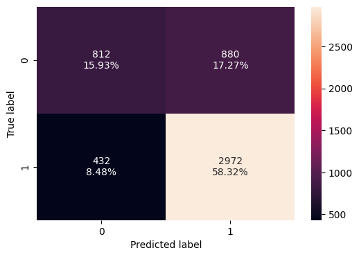

```python
# Plotting confusion matrix for final tuned XGBoost Classifier on test data
confusion_matrix(xgboost_classifier_tuned, X_test, y_test)
```

**`Observations:`**

- The final tuned XGBoost Classifier achieves a test accuracy of 0.7425, precision of 0.7715, recall of 0.8731, and F1 score of 0.8192.
- The test F1 score is very close to the validation F1 score of 0.8221, which shows that the model generalizes well on unseen data and does not show major overfitting.
- The recall value of 0.8731 indicates that the model is strong at identifying the Certified class, correctly predicting 2972 Certified cases out of 3404 actual Certified cases.
- The precision value of 0.7715 shows that among all cases predicted as Certified, a reasonable proportion are actually Certified, but there are still 880 Denied cases incorrectly classified as Certified.
- The confusion matrix shows 812 true negatives, 2972 true positives, 880 false positives, and 432 false negatives. This means the model performs better at detecting Certified cases than Denied cases.
- Overall, the tuned XGBoost Classifier is a reliable final model because its test performance is consistent with validation performance and it maintains a good balance between precision, recall, and F1 score.

## **Feature Importances of the best model**

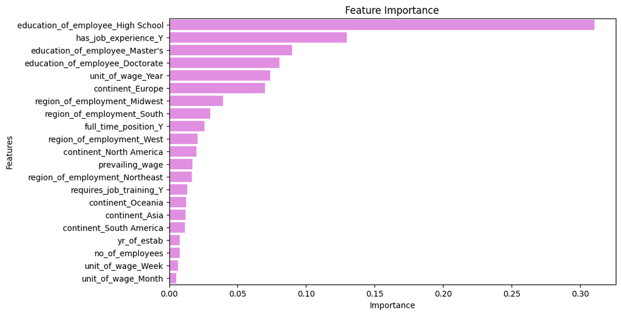

```python
# Extracting feature importance scores from the tuned XGBoost model
feature_importances = pd.Series(xgboost_classifier_tuned.feature_importances_, index=X_train.columns)

# Sorting features by importance in descending order
feature_importances_sorted = feature_importances.sort_values(ascending=False)

# Plotting feature importance of all input variables
plt.figure(figsize = (10, 6))
sns.barplot(x = feature_importances_sorted.values, y = feature_importances_sorted.index, color = 'violet')
plt.title('Feature Importance')
plt.xlabel('Importance')
plt.ylabel('Features')
plt.show()
```

**`Observations:`**

- The most influential feature in the final tuned XGBoost model is education_of_employee_High School, with an importance score of around 0.31, making it the strongest predictor by a large margin.
- has_job_experience_Y is the second most important feature, indicating that prior job experience plays a significant role in predicting visa certification outcomes.
- Education related features such as Master's, Doctorate, and High School appear among the top predictors, showing that employee education level strongly influences the model’s decisions.
- Wage related variables such as unit_of_wage_Year, prevailing_wage, unit_of_wage_Week, and unit_of_wage_Month contribute to the prediction, but their influence is lower compared to education and job experience.
- Geographic features such as employment region and continent also contribute to the model, suggesting that location based patterns have some impact on certification outcomes.
- Overall, the model relies most heavily on education level, job experience, wage structure, and regional factors, with education_of_employee_High School dominating the prediction process.